# Final Project

## 1. Motivation

Animal Crossing is one of the most popular switch game in 2020. The game's relaxed pace, gorgeous visuals, soothing soundtrack, and peaceful vibes provided a welcome contrast to the onslaught of harrowing news in the real world, and players took full advantage of that escapism. For my final project, I would like to analyze the most profitable way to play this game. Basically, the easiest way to make money is to catch and sell animals. In this project, two main kinds of species will be analyzed, fish and bugs.

The purpose of this project is that given a specific time, the result will show one or several locations to go to by finding the largest expect profit of selling species which could be found at each location.

It should be noted that all animals will show up in their routine time and time in this game is corresponding to one in the real world and poeple in different hemisphere will have different experiences.

## 2. Data Sources Description

The first two datasets I found for web scraping were:

https://animalcrossing.fandom.com/wiki/Fish_(New_Horizons)

https://animalcrossing.fandom.com/wiki/Bugs_(New_Horizons).

These two datasets include all fish and bugs the game has. We could get the basic information from them such as name, price, location, and image.

For the data achieved from external public API, the host will be

https://acnhapi.com/v1a/.

We could get the rarity of all species which we may use as a probability of show-up rate.

## 3. Data Handling

The packages needed are listed before.

```python
import pandas as pd
import seaborn as sns
import re
import numpy as np
from statistics import mean
import math
import full_dataframe as frame
```

### Read in datasets

```python
data_north  = frame.default_north()
data_south  = frame.default_south()
```

### Clean datasets

This process removes the additional information of string columns.

```python
def data_clean(dataset):
    for i in range(dataset.shape[0]):
        dataset['Price'][i] = dataset['Price'][i].replace(',','')
        location = re.sub(r'\([^()]*\)', '', dataset['Location'][i]).rstrip()
        dataset['Location'][i] = location
        rarity = re.sub(r'\([^()]*\)', '', dataset['Rarity'][i]).rstrip()
        dataset['Rarity'][i] = rarity
        if dataset['Category'][i] == 'Fish':
            shadowsize = re.sub(r'\([^()]*\)', '', dataset['Shadow size'][i]).rstrip()
            dataset['Shadow size'][i] = shadowsize
    return dataset
```

```python
data_north_clean = data_clean(data_north)
data_south_clean = data_clean(data_south)
```

### Create a new variable 'Catch Probability'

Due to different shadow sizes and rarity, there still exists some probability that players can't catch the animial even they are at the right location at right time. Therefore, a new variable is created to measure the probability of catching the species. For common species, there is 90% chance they will show up. For uncommon ones, 50%; rare ones, 30% and for ultra-rare ones, the probability is 10%. Also, fish will have different shadow sizes in river and players may miss them if they have too small shadow sizes. So from 6 to 1, the prabability of player find the species decrease from 95% to 70% by 5% and for 'narrow' size, the probability will be 60%. Players may need some skills to catch the species, so there is 90% chance of success for each attempt of catching fish and 85% for catching bugs. Therefore, the catch probability will be the product of three probabilies.

And the expected profit for each species will be catch probability times price.

```python
def prob(dataset):
    dataset['Price'] = pd.to_numeric(dataset['Price'])
    dataset['showup_prob'] = dataset['Rarity'].map({'Common':0.9,'Uncommon':0.5,'Rare':0.3,'Ultra-rare':0.1,'None':0})
    dataset['find_prob'] = dataset['Shadow size'].map({'6':0.95,'5':0.9,'4':0.85,'3':0.8,'2':0.75,'1':0.7,'Narrow':0.6})
    dataset['find_prob'] = dataset['find_prob'].fillna(1)
    dataset['success_prob'] = dataset['Category'].map({'Fish':0.9,'Bug':0.85})
    dataset['catch_prob'] = dataset['showup_prob'] * dataset['find_prob'] * dataset['success_prob']
    dataset['Price'] = dataset['Price'].replace(',','')
    dataset['profit'] = dataset['catch_prob'] * dataset['Price']
    dataset = dataset[dataset.catch_prob != 0]
    return dataset
```

```python
data_north_ready = prob(data_north_clean)
data_south_ready = prob(data_south_clean)
```

### Find optimal place according to time and month

According to the expected profit of each species and its show-up month and time, we could find the optimal place for players to go to at specific time. The main idea for this process is to find all species which will show-up and categorized them by location. Then we could find the mean profit could be achieved for different places and will go to one with highest profit. This process will find three optimal places for each hour.

```python
def find_location(month,time,north = True):
    if north == True:
        dataset = data_north_ready
        monthname = 'North_month'
    else:
        dataset = data_south_ready
        monthname = 'South_month'
    locationlist = []
    rank_1 = 'First'
    rank_2 = 'Second'
    rank_3 = 'Third'

    locationname_1 = float('nan')
    profit_1 = 0
    species_1 = 0
    rarity_1 = float('nan')
    price_1 = float('nan')
    category_1 = float('nan')


    locationname_2 = float('nan')
    profit_2 = 0
    species_2 = 0
    rarity_2 = float('nan')
    price_2 = float('nan')
    category_2 = float('nan')

    locationname_3 = float('nan')
    profit_3 = 0
    species_3 = 0
    rarity_3 = float('nan')
    price_3 = float('nan')
    category_3 = float('nan')

    for location in list(dataset.groupby('Location')):
        locationname = location[0]
        sub_dataset = location[1]
        profitlist = []
        maxspecies = ''
        maxrarity = ''
        maxprice = 0
        maxcategory = ''

        for i in sub_dataset.index.tolist():
            if month in sub_dataset[monthname][i]:
                if time in sub_dataset['Time'][i]:
                    profitlist.append(sub_dataset['profit'][i])
                    if sub_dataset['Price'][i] > maxprice:
                        maxprice = sub_dataset['Price'][i]
                        maxspecies = sub_dataset['Name'][i]
                        maxrarity = sub_dataset['Rarity'][i]
                        maxcategory = sub_dataset['Category'][i]
        if not profitlist:
            meanprofit = 0
        else:
            meanprofit = mean(profitlist)

        if meanprofit > profit_1:
            locationname_1 = locationname
            profit_1 = meanprofit
            species_1 = maxspecies
            rarity_1 = maxrarity
            price_1 = maxprice
            category_1 = maxcategory


        if meanprofit > profit_2 and meanprofit < profit_1:
            locationname_2 = locationname
            profit_2 = meanprofit
            species_2 = maxspecies
            rarity_2 = maxrarity
            price_2 = maxprice
            category_2 = maxcategory
            rank_2 = 'Second'

        if meanprofit > profit_3 and meanprofit < profit_2:
            locationname_3 = locationname
            profit_3 = meanprofit
            species_3 = maxspecies
            rarity_3 = maxrarity
            price_3 = maxprice
            category_3 = maxcategory
            rank_3 = 'Third'

        locationlist = [locationname_1,rank_1,profit_1,species_1,rarity_1,price_1,category_1,
                        locationname_2,rank_2,profit_2,species_2,rarity_2,price_2,category_2,
                        locationname_3,rank_3,profit_3,species_3,rarity_3,price_3,category_3]
    return locationlist
```

### Create final dataframe for analysis

From the above function, we find most 3 profitable places with expected profit, most valuable species and its price and category. So we are going to include all the information and create a dataset for final analysis.

```python
month = np.repeat(np.repeat(range(1,13),3),24)
time = list(np.repeat(range(0,24),3))*12
timedict = {'Month':month,'Time':time,'Optimal Location':''*3*12*24,
            'Rank':''*3*12*24,'Optimal Profit':''*3*24*12,'Most Valued Species':''*3*24*12,
            'Rarity':''*3*24*12,'Price':''*3*24*12,'Category':''*3*24*12}
optimallocation = pd.DataFrame(timedict)
```

```python
def location_summary(dataset,north = True):
    for i in range(12*24):
        optimallist = find_location(dataset['Month'][i],dataset['Time'][i],north)
        for j in range(3):
            for k in range(7):
                dataset.iloc[i*3+j,k+2] = optimallist[j*7 + k]
    return dataset
```

```python
north = location_summary(optimallocation,north = True)
north['Optimal Profit'] = pd.to_numeric(north['Optimal Profit'])
north.head()
```

|  | Month | Time | Optimal Location | Rank | Optimal Profit | Most Valued Species | Rarity | Price | Category |
| --- | --- | --- | --- | --- | --- | --- | --- | --- | --- |
| 0 | 1 | 0 | On the Ground | First | 4207.50000 | Tarantula | Common | 8000 | Bug |
| 1 | 1 | 0 | Pier | Second | 2180.25000 | Blue marlin | Rare | 10000 | Fish |
| 2 | 1 | 0 | Sea | Third | 956.38125 | Barreleye | Ultra-rare | 15000 | Fish |
| 3 | 1 | 1 | On the Ground | First | 4207.50000 | Tarantula | Common | 8000 | Bug |
| 4 | 1 | 1 | Pier | Second | 2180.25000 | Blue marlin | Rare | 10000 | Fish |

```python
south = location_summary(optimallocation,north = False)
south['Optimal Profit'] = pd.to_numeric(north['Optimal Profit'])
south.head()
```

|  | Month | Time | Optimal Location | Rank | Optimal Profit | Most Valued Species | Rarity | Price | Category |
| --- | --- | --- | --- | --- | --- | --- | --- | --- | --- |
| 0 | 1 | 0 | On the ground | First | 2329.000000 | Scorpion | Common | 8000 | Bug |
| 1 | 1 | 0 | Pier | Second | 1948.500000 | Blue marlin | Rare | 10000 | Fish |
| 2 | 1 | 0 | Sea | Third | 1333.480263 | Great white shark | Rare | 15000 | Fish |
| 3 | 1 | 1 | On the ground | First | 2329.000000 | Scorpion | Common | 8000 | Bug |
| 4 | 1 | 1 | Pier | Second | 1948.500000 | Blue marlin | Rare | 10000 | Fish |

## 4. Data visualization and Analysis

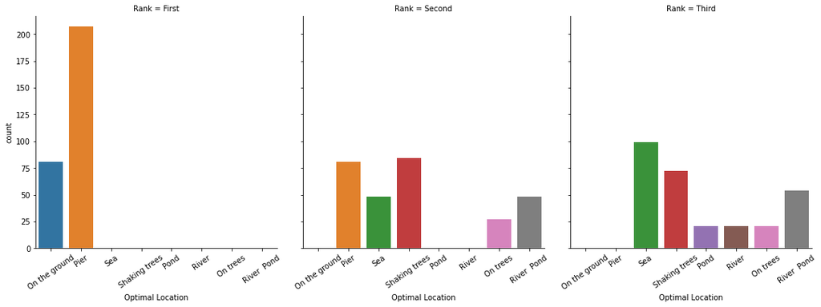

```python
g1 = sns.catplot(x = 'Optimal Location',col = 'Rank',data = north, kind='count')
g1.set_xticklabels(rotation=35)
```

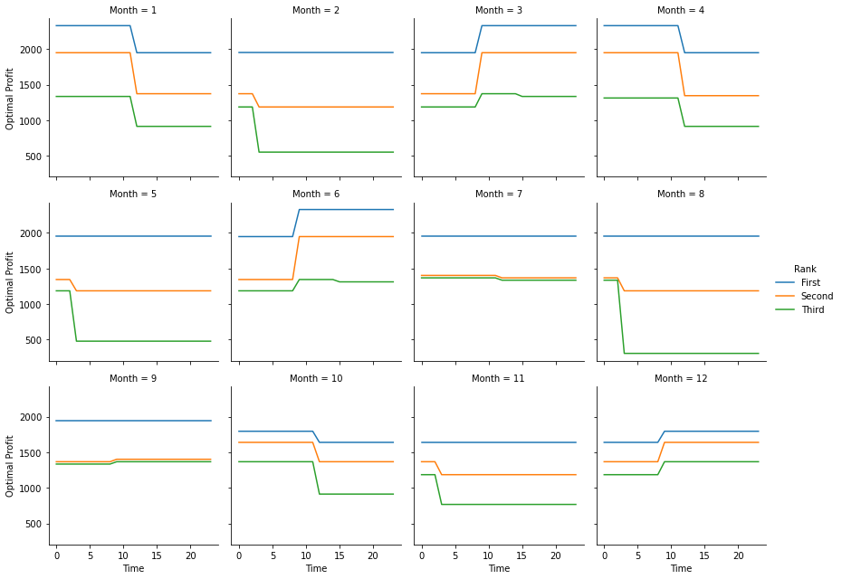

```python
g2 = sns.FacetGrid(north,col = 'Month',hue = 'Rank',col_wrap = 4)
g2.map(sns.lineplot,'Time','Optimal Profit')
g2.add_legend(title='Rank')
```

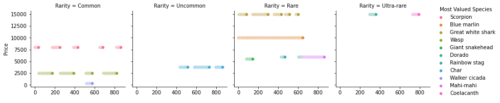

```python
north_g3 = north
north_g3['rownumber'] = north.index
g3 = sns.FacetGrid(north,col = 'Rarity',hue = 'Most Valued Species',
                   col_order = ['Common','Uncommon','Rare','Ultra-rare'])
g3.map(sns.scatterplot,'rownumber','Price')
for i in range(4):
    g3.axes[0,i].set_xlabel('')
g3.add_legend(title='Most Valued Species')
```